# 🌡️ Temperature Forecasting using Prophet

## 📈 Forecasting Daily Minimum Temperature

### Module 5 — Time Series Forecasting

**Prepared by:** Lovisha Jaat **Algorithm:** Facebook Prophet  
**Dataset:** Daily Minimum Temperature Dataset

## 🎯 1. Objective

The objective of this notebook is to develop a time-series forecasting model using the **Prophet algorithm**.

The model will analyse historical daily minimum temperature observations and forecast future temperatures.

The notebook covers:

- Data loading and inspection
- Data preprocessing
- Time-series visualization
- Chronological train-test splitting
- Prophet model building
- Model training
- Temperature forecasting
- Forecast visualization
- MAE, RMSE and MAPE evaluation
- Future temperature forecasting

## 📝 2. Problem Statement

Weather forecasting is important for agriculture, transportation, tourism, energy management and daily planning.

The goal of this project is to build a Prophet forecasting model capable of predicting future daily minimum temperatures from historical temperature observations.

Prophet is suitable for this task because it can automatically model:

- Long-term trends
- Weekly seasonality
- Yearly seasonality
- Changes in time-series patterns
- Missing or irregular observations

## 📂 3. Dataset Description

We will use the **Daily Minimum Temperature Dataset**.

The dataset contains daily minimum temperatures recorded in Melbourne, Australia.

### Dataset columns

| Column | Description |
| --- | --- |
| Date | Date of the temperature observation |
| Temp | Daily minimum temperature in degrees Celsius |

### Dataset properties

- **Time frequency:** Daily
- **Target variable:** Minimum temperature
- **Problem type:** Univariate time-series forecasting
- **Measurement unit:** Degrees Celsius

## ⚙️ 4. Installing Prophet

Prophet is an external Python library and may not be installed by default.

Run the following cell once. If Prophet is already installed, you can skip this step.

```python
%pip install prophet -q
```

## 📦 5. Import Required Libraries

The following libraries will be used:

- **Pandas:** Data loading and manipulation
- **NumPy:** Numerical calculations
- **Matplotlib:** Data visualization
- **Prophet:** Time-series forecasting
- **Scikit-learn:** Model evaluation

```python
import warnings
warnings.filterwarnings("ignore")

import pandas as pd
import numpy as np
import matplotlib.pyplot as plt

from prophet import Prophet

from sklearn.metrics import (
    mean_absolute_error,
    mean_squared_error
)
```

## 📥 6. Dataset Loading

The Daily Minimum Temperature Dataset will be loaded from a public data repository.

After loading the dataset, we will display its first few records.

```python
url = "https://raw.githubusercontent.com/jbrownlee/Datasets/master/daily-min-temperatures.csv"

df = pd.read_csv(url)

df.head()
```

|  | Date | Temp |
| --- | --- | --- |
| 0 | 1981-01-01 | 20.7 |
| 1 | 1981-01-02 | 17.9 |
| 2 | 1981-01-03 | 18.8 |
| 3 | 1981-01-04 | 14.6 |
| 4 | 1981-01-05 | 15.8 |

## 🔍 7. Initial Dataset Inspection

Before preparing the forecasting model, we will inspect:

- Dataset shape
- Column names
- Data types
- Missing values
- Duplicate records
- Statistical summary

```python
print("Dataset Shape:", df.shape)

print("\nColumn Names:")
print(df.columns.tolist())

print("\nData Types:")
print(df.dtypes)

print("\nMissing Values:")
print(df.isnull().sum())

print("\nDuplicate Rows:")
print(df.duplicated().sum())

print("\nStatistical Summary:")
display(df.describe())
```

```
Dataset Shape: (3650, 2)

Column Names:
['Date', 'Temp']

Data Types:
Date     object
Temp    float64
dtype: object

Missing Values:
Date    0
Temp    0
dtype: int64

Duplicate Rows:
0

Statistical Summary:
```

|  | Temp |
| --- | --- |
| count | 3650.000000 |
| mean | 11.177753 |
| std | 4.071837 |
| min | 0.000000 |
| 25% | 8.300000 |
| 50% | 11.000000 |
| 75% | 14.000000 |
| max | 26.300000 |

## 🛠️ 8. Data Preprocessing

Prophet requires two specially named columns:

- `ds`: Date or timestamp column
- `y`: Numerical target column

Therefore, we will:

1. Convert the Date column into datetime format
2. Rename Date as `ds`
3. Rename Temp as `y`
4. Sort the observations chronologically
5. Remove duplicate dates
6. Handle missing temperature values

```python
df["Date"] = pd.to_datetime(df["Date"], errors="coerce")

df = df.rename(columns={
    "Date": "ds",
    "Temp": "y"
})

df = df.sort_values("ds")

df = df.drop_duplicates(subset="ds")

df.head()
```

|  | ds | y |
| --- | --- | --- |
| 0 | 1981-01-01 | 20.7 |
| 1 | 1981-01-02 | 17.9 |
| 2 | 1981-01-03 | 18.8 |
| 3 | 1981-01-04 | 14.6 |
| 4 | 1981-01-05 | 15.8 |

## 🧹 9. Handling Missing Values

Missing dates or temperature values can affect forecasting accuracy.

We will:

- Remove records with invalid dates
- Convert the target column to numeric
- Use interpolation to fill missing temperature observations

```python
df["y"] = pd.to_numeric(df["y"], errors="coerce")

df = df.dropna(subset=["ds"])

df["y"] = df["y"].interpolate(
    method="linear",
    limit_direction="both"
)

print("Missing Values After Cleaning:")
print(df.isnull().sum())

print("\nCleaned Dataset Shape:", df.shape)
```

```
Missing Values After Cleaning:
ds    0
y     0
dtype: int64

Cleaned Dataset Shape: (3650, 2)
```

## 📅 10. Time-Series Range

We will now check:

- Starting date
- Ending date
- Total observations
- Minimum temperature
- Maximum temperature
- Average temperature

```python
print("Starting Date:", df["ds"].min())
print("Ending Date:", df["ds"].max())
print("Total Observations:", len(df))

print("\nMinimum Temperature:", df["y"].min(), "°C")
print("Maximum Temperature:", df["y"].max(), "°C")
print("Average Temperature:", round(df["y"].mean(), 2), "°C")
```

```
Starting Date: 1981-01-01 00:00:00
Ending Date: 1990-12-31 00:00:00
Total Observations: 3650

Minimum Temperature: 0.0 °C
Maximum Temperature: 26.3 °C
Average Temperature: 11.18 °C
```

## 📈 11. Historical Temperature Visualization

The following graph shows how daily minimum temperature changes over time.

This visualization helps identify:

- Seasonal fluctuations
- Long-term temperature patterns
- Unusually high or low observations
- Yearly repeating behaviour

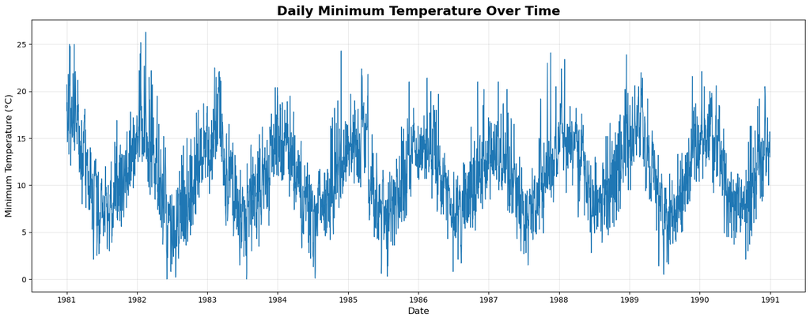

```python
plt.figure(figsize=(15, 6))

plt.plot(
    df["ds"],
    df["y"],
    linewidth=1
)

plt.title(
    "Daily Minimum Temperature Over Time",
    fontsize=17,
    fontweight="bold"
)
plt.xlabel("Date", fontsize=12)
plt.ylabel("Minimum Temperature (°C)", fontsize=12)
plt.grid(alpha=0.3)
plt.tight_layout()
plt.show()
```

## 📊 12. Rolling Average Analysis

Daily temperature data may contain frequent short-term fluctuations.

A 30-day rolling average smooths the series and makes the overall temperature pattern easier to understand.

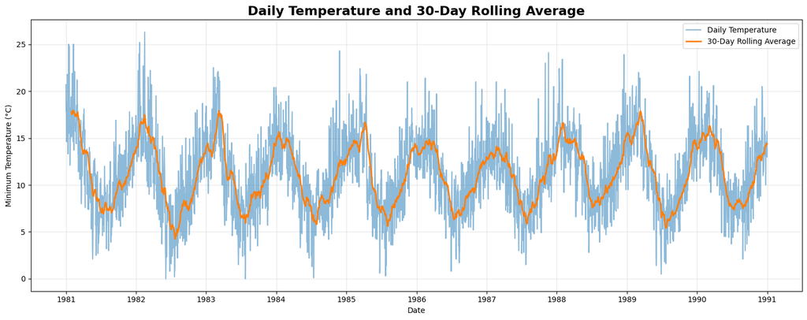

```python
df["30_Day_Rolling_Mean"] = df["y"].rolling(window=30).mean()

plt.figure(figsize=(15, 6))

plt.plot(
    df["ds"],
    df["y"],
    label="Daily Temperature",
    alpha=0.5
)

plt.plot(
    df["ds"],
    df["30_Day_Rolling_Mean"],
    label="30-Day Rolling Average",
    linewidth=2
)

plt.title(
    "Daily Temperature and 30-Day Rolling Average",
    fontsize=17,
    fontweight="bold"
)
plt.xlabel("Date")
plt.ylabel("Minimum Temperature (°C)")
plt.legend()
plt.grid(alpha=0.3)
plt.tight_layout()
plt.show()
```

## 🗓️ 13. Monthly Temperature Analysis

To understand yearly seasonality, we will calculate the average minimum temperature for each month.

This helps identify warmer and cooler periods of the year.

```python
monthly_average = (
    df.assign(Month=df["ds"].dt.month)
      .groupby("Month")["y"]
      .mean()
)

monthly_average
```

```
Month
1     15.030323
2     15.373759
3     14.565484
4     12.088333
5      9.866452
6      7.278333
7      6.692581
8      7.891290
9      8.976333
10    10.309355
11    12.479667
12    13.851948
Name: y, dtype: float64
```

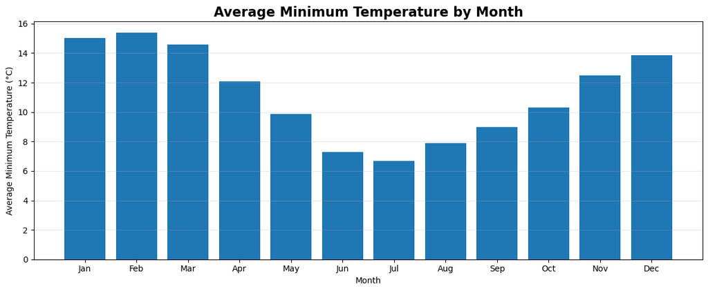

```python
month_names = [
    "Jan", "Feb", "Mar", "Apr",
    "May", "Jun", "Jul", "Aug",
    "Sep", "Oct", "Nov", "Dec"
]

plt.figure(figsize=(12, 5))

plt.bar(month_names, monthly_average.values)

plt.title(
    "Average Minimum Temperature by Month",
    fontsize=16,
    fontweight="bold"
)
plt.xlabel("Month")
plt.ylabel("Average Minimum Temperature (°C)")
plt.grid(axis="y", alpha=0.3)
plt.tight_layout()
plt.show()
```

## ✂️ 14. Train-Test Split

Time-series observations must remain in chronological order.

Random shuffling is not appropriate because future observations should not be used to predict past values.

We will use:

- All observations except the final 365 days for training
- The final 365 days for testing

The testing dataset therefore represents approximately one complete year.

```python
test_days = 365

train = df[["ds", "y"]].iloc[:-test_days].copy()
test = df[["ds", "y"]].iloc[-test_days:].copy()

print("Training Observations:", len(train))
print("Testing Observations:", len(test))

print("\nTraining Period:")
print(train["ds"].min(), "to", train["ds"].max())

print("\nTesting Period:")
print(test["ds"].min(), "to", test["ds"].max())
```

```
Training Observations: 3285
Testing Observations: 365

Training Period:
1981-01-01 00:00:00 to 1989-12-31 00:00:00

Testing Period:
1990-01-01 00:00:00 to 1990-12-31 00:00:00
```

## 📉 15. Training and Testing Data Visualization

The following graph displays the chronological division of the dataset.

- The training section is used to learn temperature patterns.
- The testing section is used to evaluate forecasting performance.

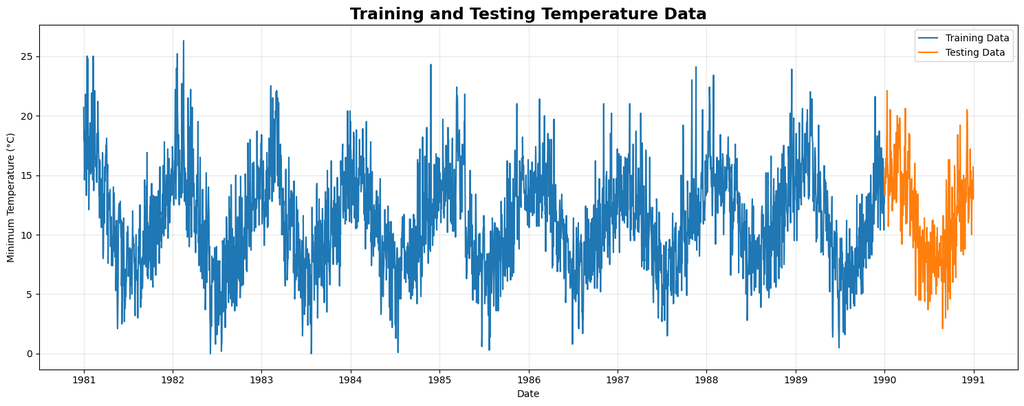

```python
plt.figure(figsize=(15, 6))

plt.plot(
    train["ds"],
    train["y"],
    label="Training Data"
)

plt.plot(
    test["ds"],
    test["y"],
    label="Testing Data"
)

plt.title(
    "Training and Testing Temperature Data",
    fontsize=17,
    fontweight="bold"
)
plt.xlabel("Date")
plt.ylabel("Minimum Temperature (°C)")
plt.legend()
plt.grid(alpha=0.3)
plt.tight_layout()
plt.show()
```

## 🤖 16. Prophet Model Building

Prophet models a time series using major components such as:

- **Trend:** Long-term increase or decrease
- **Yearly seasonality:** Patterns repeating every year
- **Weekly seasonality:** Patterns repeating every week
- **Holiday effects:** Changes caused by special events, when supplied

For daily temperature data:

- Yearly seasonality is important.
- Weekly seasonality is not expected to have a major physical meaning.
- Daily seasonality is unnecessary because there is one observation per day.

```python
prophet_model = Prophet(
    yearly_seasonality=True,
    weekly_seasonality=False,
    daily_seasonality=False,
    seasonality_mode="additive",
    interval_width=0.95
)
```

## 🏋️ 17. Model Training

The Prophet model will now be trained using the historical training dataset.

During training, the model learns:

- Long-term temperature trends
- Repeating yearly temperature patterns
- Seasonal variation
- Changes in the time-series growth pattern

```python
prophet_model.fit(train)
```

```
00:04:54 - cmdstanpy - INFO - Chain [1] start processing
00:04:59 - cmdstanpy - INFO - Chain [1] done processing
```

```
<prophet.forecaster.Prophet at 0x24bf3915e80>
```

## 📅 18. Preparing Dates for Prediction

Prophet requires a DataFrame containing a `ds` column for the dates that need to be forecasted.

We will provide the dates available in the testing dataset.

```python
test_dates = test[["ds"]].copy()

test_dates.head()
```

|  | ds |
| --- | --- |
| 3285 | 1990-01-01 |
| 3286 | 1990-01-02 |
| 3287 | 1990-01-03 |
| 3288 | 1990-01-04 |
| 3289 | 1990-01-05 |

## 🔮 19. Temperature Forecasting

The trained Prophet model will now forecast minimum temperatures for every date in the testing period.

Prophet returns several columns, including:

- `yhat`: Forecasted temperature
- `yhat_lower`: Lower forecast limit
- `yhat_upper`: Upper forecast limit
- Trend and seasonal components

```python
forecast = prophet_model.predict(test_dates)

forecast[
    ["ds", "yhat", "yhat_lower", "yhat_upper"]
].head()
```

|  | ds | yhat | yhat_lower | yhat_upper |
| --- | --- | --- | --- | --- |
| 0 | 1990-01-01 | 14.851055 | 9.711926 | 20.290288 |
| 1 | 1990-01-02 | 14.914131 | 9.357358 | 20.227992 |
| 2 | 1990-01-03 | 14.974986 | 9.737992 | 20.061964 |
| 3 | 1990-01-04 | 15.032813 | 9.741954 | 20.257468 |
| 4 | 1990-01-05 | 15.086868 | 9.652461 | 20.258350 |

## 📏 20. Model Evaluation

The Prophet model will be evaluated using three metrics.

### Mean Absolute Error

MAE measures the average absolute difference between actual and predicted temperatures.

### Root Mean Squared Error

RMSE gives greater importance to large forecasting errors.

### Mean Absolute Percentage Error

MAPE expresses the average forecasting error as a percentage.

Lower MAE, RMSE and MAPE values indicate better model performance.

```python
actual = test["y"].to_numpy()
predicted = forecast["yhat"].to_numpy()

mae = mean_absolute_error(actual, predicted)

rmse = np.sqrt(
    mean_squared_error(actual, predicted)
)

non_zero = actual != 0

mape = np.mean(
    np.abs(
        (actual[non_zero] - predicted[non_zero])
        / actual[non_zero]
    )
) * 100

print("Prophet Model Evaluation")
print("-" * 35)
print(f"MAE  : {mae:.2f} °C")
print(f"RMSE : {rmse:.2f} °C")
print(f"MAPE : {mape:.2f}%")
```

```
Prophet Model Evaluation
-----------------------------------
MAE  : 1.93 °C
RMSE : 2.51 °C
MAPE : 19.74%
```

## 📉 21. Forecast Visualization

The following visualization compares:

- Historical training temperatures
- Actual testing temperatures
- Prophet forecasted temperatures
- 95% uncertainty interval

Forecast values closer to actual values indicate better model performance.

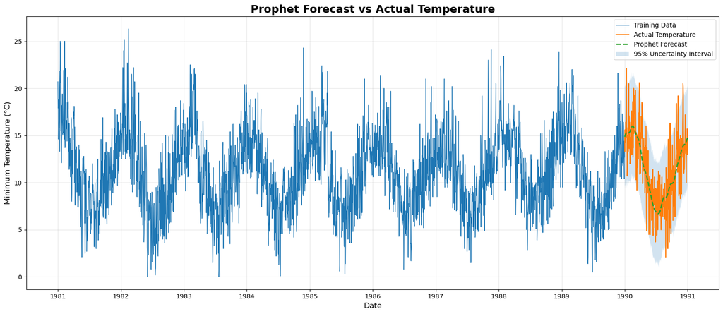

```python
plt.figure(figsize=(16, 7))

plt.plot(
    train["ds"],
    train["y"],
    label="Training Data",
    linewidth=1
)

plt.plot(
    test["ds"],
    test["y"],
    label="Actual Temperature",
    linewidth=1.5
)

plt.plot(
    forecast["ds"],
    forecast["yhat"],
    label="Prophet Forecast",
    linestyle="--",
    linewidth=2
)

plt.fill_between(
    forecast["ds"],
    forecast["yhat_lower"],
    forecast["yhat_upper"],
    alpha=0.2,
    label="95% Uncertainty Interval"
)

plt.title(
    "Prophet Forecast vs Actual Temperature",
    fontsize=17,
    fontweight="bold"
)
plt.xlabel("Date", fontsize=12)
plt.ylabel("Minimum Temperature (°C)", fontsize=12)
plt.legend()
plt.grid(alpha=0.3)
plt.tight_layout()
plt.show()
```

## 🔎 22. Testing Period Forecast Close-Up

The following graph displays only the testing period.

This provides a clearer comparison between actual and forecasted daily temperatures.

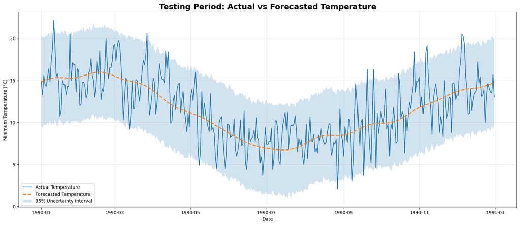

```python
plt.figure(figsize=(16, 7))

plt.plot(
    test["ds"],
    test["y"],
    label="Actual Temperature",
    linewidth=1.5
)

plt.plot(
    forecast["ds"],
    forecast["yhat"],
    label="Forecasted Temperature",
    linestyle="--",
    linewidth=2
)

plt.fill_between(
    forecast["ds"],
    forecast["yhat_lower"],
    forecast["yhat_upper"],
    alpha=0.2,
    label="95% Uncertainty Interval"
)

plt.title(
    "Testing Period: Actual vs Forecasted Temperature",
    fontsize=17,
    fontweight="bold"
)
plt.xlabel("Date")
plt.ylabel("Minimum Temperature (°C)")
plt.legend()
plt.grid(alpha=0.3)
plt.tight_layout()
plt.show()
```

## 📋 23. Actual and Forecasted Values

The following table provides a date-wise comparison of:

- Actual temperature
- Forecasted temperature
- Lower forecast limit
- Upper forecast limit
- Absolute forecasting error

```python
results = pd.DataFrame({
    "Date": test["ds"].to_numpy(),
    "Actual Temperature": actual,
    "Forecasted Temperature": predicted,
    "Lower Limit": forecast["yhat_lower"].to_numpy(),
    "Upper Limit": forecast["yhat_upper"].to_numpy()
})

results["Absolute Error"] = np.abs(
    results["Actual Temperature"]
    - results["Forecasted Temperature"]
)

results.head(15).round(2)
```

|  | Date | Actual Temperature | Forecasted Temperature | Lower Limit | Upper Limit | Absolute Error |
| --- | --- | --- | --- | --- | --- | --- |
| 0 | 1990-01-01 | 14.8 | 14.85 | 9.71 | 20.29 | 0.05 |
| 1 | 1990-01-02 | 13.3 | 14.91 | 9.36 | 20.23 | 1.61 |
| 2 | 1990-01-03 | 15.6 | 14.97 | 9.74 | 20.06 | 0.63 |
| 3 | 1990-01-04 | 14.5 | 15.03 | 9.74 | 20.26 | 0.53 |
| 4 | 1990-01-05 | 14.3 | 15.09 | 9.65 | 20.26 | 0.79 |
| 5 | 1990-01-06 | 15.3 | 15.14 | 9.99 | 20.38 | 0.16 |
| 6 | 1990-01-07 | 16.4 | 15.18 | 9.73 | 20.67 | 1.22 |
| 7 | 1990-01-08 | 14.8 | 15.22 | 10.29 | 20.22 | 0.42 |
| 8 | 1990-01-09 | 17.4 | 15.25 | 9.67 | 20.84 | 2.15 |
| 9 | 1990-01-10 | 18.8 | 15.28 | 9.94 | 20.53 | 3.52 |
| 10 | 1990-01-11 | 22.1 | 15.30 | 9.78 | 21.04 | 6.80 |
| 11 | 1990-01-12 | 19.0 | 15.32 | 10.32 | 21.21 | 3.68 |
| 12 | 1990-01-13 | 15.5 | 15.33 | 9.78 | 20.52 | 0.17 |
| 13 | 1990-01-14 | 15.8 | 15.34 | 9.42 | 20.70 | 0.46 |
| 14 | 1990-01-15 | 14.7 | 15.34 | 10.18 | 20.59 | 0.64 |

## 🧩 24. Prophet Forecast Components

Prophet separates the forecast into interpretable components.

For this temperature dataset, the important components include:

- **Trend:** Long-term movement in temperature
- **Yearly seasonality:** Repeating annual temperature cycle

The component plots help us understand how each pattern contributes to the final forecast.

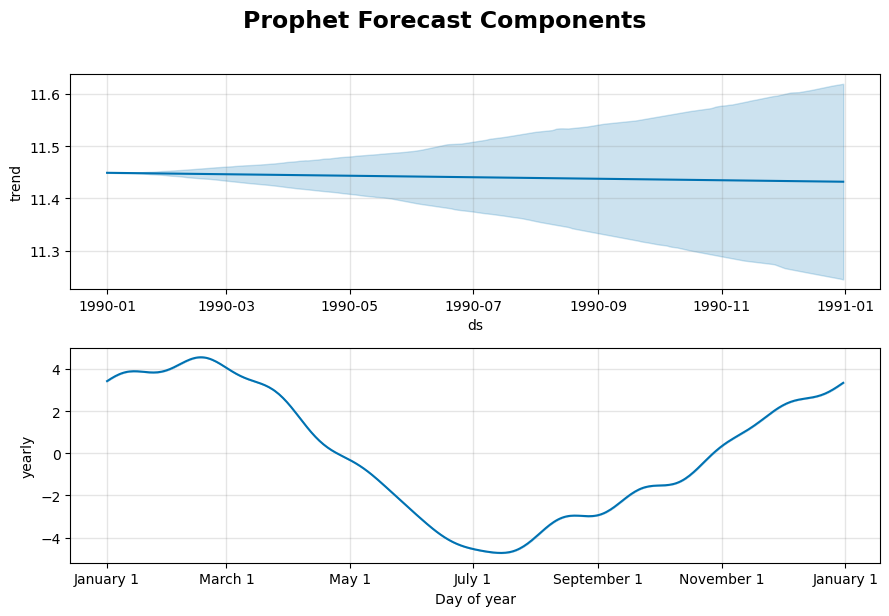

```python
prophet_model.plot_components(forecast)

plt.suptitle(
    "Prophet Forecast Components",
    fontsize=17,
    fontweight="bold",
    y=1.02
)

plt.tight_layout()
plt.show()
```

## 💡 25. Result Interpretation

The Prophet model learns the long-term and seasonal patterns present in daily temperature data.

The results can be interpreted as follows:

- A lower MAE indicates a smaller average temperature prediction error.
- A lower RMSE indicates fewer large forecasting errors.
- A lower MAPE indicates better percentage-based accuracy.
- Forecasts close to actual observations indicate good model performance.
- The uncertainty interval represents the possible range of future temperature values.
- Yearly seasonality shows how temperature patterns repeat across different months.

Daily weather may also be affected by unexpected atmospheric conditions, so exact forecasts are difficult and some error is natural.

## 🚀 26. Training the Final Prophet Model

After evaluating the model, we will train a new Prophet model using the complete dataset.

This allows the final model to learn from all available temperature observations before forecasting future dates.

```python
final_data = df[["ds", "y"]].copy()

final_model = Prophet(
    yearly_seasonality=True,
    weekly_seasonality=False,
    daily_seasonality=False,
    seasonality_mode="additive",
    interval_width=0.95
)

final_model.fit(final_data)
```

```
00:07:34 - cmdstanpy - INFO - Chain [1] start processing
00:07:34 - cmdstanpy - INFO - Chain [1] done processing
```

```
<prophet.forecaster.Prophet at 0x24bf4735d10>
```

## 📆 27. Creating Future Dates

We will create daily timestamps for the next 365 days.

The future DataFrame contains:

- Historical dates
- 365 new future dates

```python
future_dates = final_model.make_future_dataframe(
    periods=365,
    freq="D"
)

future_dates.tail()
```

|  | ds |
| --- | --- |
| 4010 | 1991-12-27 |
| 4011 | 1991-12-28 |
| 4012 | 1991-12-29 |
| 4013 | 1991-12-30 |
| 4014 | 1991-12-31 |

## 🔭 28. Forecasting the Next 365 Days

The final Prophet model will now forecast daily minimum temperatures for the next year.

The output contains:

- Predicted temperature
- Lower uncertainty limit
- Upper uncertainty limit
- Trend and seasonal components

```python
future_forecast = final_model.predict(future_dates)

future_forecast[
    ["ds", "yhat", "yhat_lower", "yhat_upper"]
].tail()
```

|  | ds | yhat | yhat_lower | yhat_upper |
| --- | --- | --- | --- | --- |
| 4010 | 1991-12-27 | 14.528008 | 9.185480 | 20.012980 |
| 4011 | 1991-12-28 | 14.586755 | 9.475665 | 19.155174 |
| 4012 | 1991-12-29 | 14.650981 | 9.086613 | 20.084806 |
| 4013 | 1991-12-30 | 14.719937 | 9.736543 | 20.113574 |
| 4014 | 1991-12-31 | 14.792719 | 9.727324 | 19.945685 |

## 📑 29. Future Temperature Forecast Table

The following table displays the predicted minimum temperatures for the next 365 days.

Only future dates are selected from the complete forecast.

```python
last_historical_date = final_data["ds"].max()

future_only = future_forecast[
    future_forecast["ds"] > last_historical_date
][
    ["ds", "yhat", "yhat_lower", "yhat_upper"]
].copy()

future_only.columns = [
    "Date",
    "Forecasted Temperature",
    "Lower Limit",
    "Upper Limit"
]

future_only.head(15).round(2)
```

|  | Date | Forecasted Temperature | Lower Limit | Upper Limit |
| --- | --- | --- | --- | --- |
| 3650 | 1991-01-01 | 14.87 | 9.50 | 20.26 |
| 3651 | 1991-01-02 | 14.95 | 9.55 | 20.30 |
| 3652 | 1991-01-03 | 15.03 | 9.58 | 20.04 |
| 3653 | 1991-01-04 | 15.10 | 9.97 | 20.15 |
| 3654 | 1991-01-05 | 15.18 | 10.26 | 20.65 |
| 3655 | 1991-01-06 | 15.25 | 10.08 | 20.39 |
| 3656 | 1991-01-07 | 15.31 | 9.84 | 20.22 |
| 3657 | 1991-01-08 | 15.37 | 10.28 | 20.79 |
| 3658 | 1991-01-09 | 15.43 | 10.10 | 20.71 |
| 3659 | 1991-01-10 | 15.47 | 10.36 | 20.50 |
| 3660 | 1991-01-11 | 15.51 | 9.79 | 20.69 |
| 3661 | 1991-01-12 | 15.54 | 10.41 | 20.97 |
| 3662 | 1991-01-13 | 15.56 | 10.16 | 21.08 |
| 3663 | 1991-01-14 | 15.58 | 10.44 | 20.94 |
| 3664 | 1991-01-15 | 15.58 | 10.46 | 20.92 |

## 📊 30. Future Temperature Forecast Visualization

The final graph displays:

- Historical minimum temperatures
- Forecasted temperatures for the next 365 days
- Forecast uncertainty interval

This visualization shows the expected yearly temperature cycle.

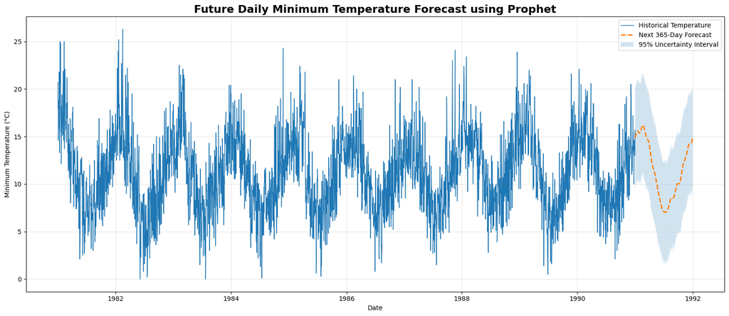

```python
future_only_plot = future_forecast[
    future_forecast["ds"] > last_historical_date
].copy()

plt.figure(figsize=(16, 7))

plt.plot(
    final_data["ds"],
    final_data["y"],
    label="Historical Temperature",
    linewidth=1
)

plt.plot(
    future_only_plot["ds"],
    future_only_plot["yhat"],
    label="Next 365-Day Forecast",
    linestyle="--",
    linewidth=2
)

plt.fill_between(
    future_only_plot["ds"],
    future_only_plot["yhat_lower"],
    future_only_plot["yhat_upper"],
    alpha=0.2,
    label="95% Uncertainty Interval"
)

plt.title(
    "Future Daily Minimum Temperature Forecast using Prophet",
    fontsize=17,
    fontweight="bold"
)
plt.xlabel("Date")
plt.ylabel("Minimum Temperature (°C)")
plt.legend()
plt.grid(alpha=0.3)
plt.tight_layout()
plt.show()
```

## 🌍 31. Complete Prophet Forecast

Prophet provides a built-in forecast visualization containing:

- Historical observations
- Forecasted trend
- Future predictions
- Forecast uncertainty

This provides an overall view of the complete time-series forecast.

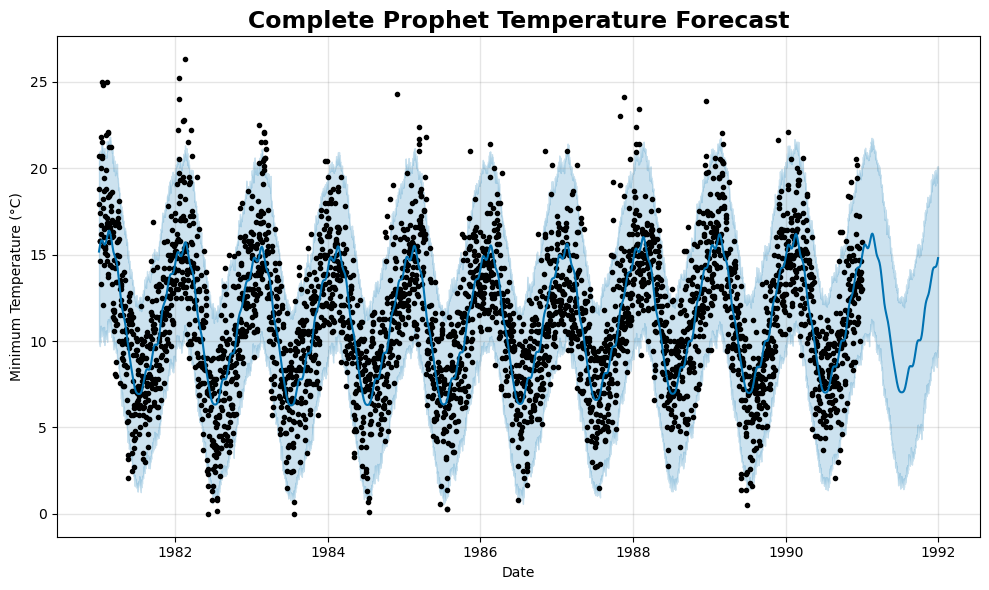

```python
final_model.plot(future_forecast)

plt.title(
    "Complete Prophet Temperature Forecast",
    fontsize=17,
    fontweight="bold"
)
plt.xlabel("Date")
plt.ylabel("Minimum Temperature (°C)")
plt.tight_layout()
plt.show()
```

## ✅ 32. Conclusion

In this notebook, we successfully implemented the **Prophet time-series forecasting algorithm** to predict daily minimum temperatures.

### Tasks completed

- Loaded the Daily Minimum Temperature Dataset
- Inspected and cleaned the dataset
- Converted columns into Prophet format
- Visualized historical temperature observations
- Analysed rolling and monthly temperature patterns
- Created a chronological train-test split
- Built and trained the Prophet model
- Forecasted testing-period temperatures
- Evaluated the model using MAE, RMSE and MAPE
- Visualized actual and forecasted temperatures
- Analysed Prophet trend and yearly seasonal components
- Trained a final model on the complete dataset
- Forecasted minimum temperatures for the next 365 days

Prophet is a flexible and interpretable forecasting algorithm that works effectively with time-series data containing trend and seasonal patterns.